# Programming Assignment 3

George Papadopoulos pgeorgios8@gmail.com

2023-04-08

## Introduction

The Hospital Compare web site contains a lot of data and we will only look at a small subset for this assignment. The zip file for this assignment contains three files

- outcome-of-care-measures.csv: Contains information about 30-day mortality and readmission rates for heart attacks, heart failure, and pneumonia for over 4,000 hospitals.
- hospital-data.csv: Contains information about each hospital.
- Hospital_Revised_Flatfiles.pdf: Descriptions of the variables in each file. A description of the variables in each of the files is in the included PDF file named Hospital_Revised_Flatfiles.pdf. This document contains information about many other files that are not included with this programming assignment.

You will want to focus on the variables for number 19 (“Outcome of Care Measures.csv”) and number 11 (“HospitalData.csv”). You may find it useful to print out this document (at least the pages for Tables 19 and 11) to have next to you while you work on this assignment. In particular, the numbers of the variables for each table indicate column indices in each table (i.e. “Hospital Name” is column 2 in the outcome-of-care-measures.csv file).

### 1 Plot the 30-day mortality rates for heart attack

```r
data <- read.csv("outcome-of-care-measures.csv",colClasses = "character")
##head(data)
```

There are many columns in this dataset. You can see how many by typing ncol(outcome) (you can see the number of rows with the **nrow** function). In addition, you can see the names of each column by typing names(outcome) (the names are also in the PDF document).To make a simple histogram of the 30-day death rates from heart attack (column 11 in the outcome dataset).

```r
data[,11] <- as.numeric(data[,11])
```

```
Warning: NAs introduced by coercion
```

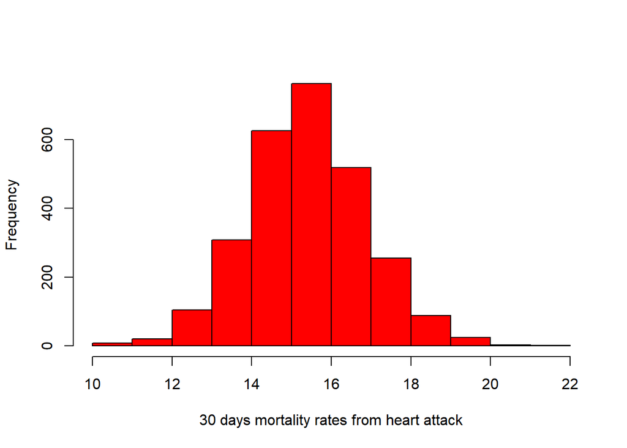

```r
## you may get a warning about NAs being introduced; that is okay
hist(data[,11],xlab = "30 days mortality rates from heart attack",main = "",col = 'red')
```

Because we originally read the data in as character by specifying colClasses = “character” we need to coerce the column to be numeric. You may get a warning about NAs being introduced but that is okay.

```r
data <- data[,c(2,7,11,17,23)]
data[,4] <- as.numeric(data[,4])
```

```
Warning: NAs introduced by coercion
```

```r
data[,5] <- as.numeric(data[,5])
```

```
Warning: NAs introduced by coercion
```